# bank_data_eda

```python
import numpy as np
import pandas as pd
import seaborn as sns
from matplotlib import pyplot as plt
```

```python
bank_data = pd.read_csv("./Data/bank_train_data.csv", index_col=0)
bank_data
```

|  | age | job | marital | education | default | balance | housing | loan | contact | day | month | duration | campaign | pdays | previous | poutcome | y |
| --- | --- | --- | --- | --- | --- | --- | --- | --- | --- | --- | --- | --- | --- | --- | --- | --- | --- |
| 0 | 37 | entrepreneur | single | tertiary | no | 1467 | yes | yes | cellular | 17 | nov | 349 | 1 | -1 | 0 | unknown | no |
| 1 | 25 | unemployed | single | secondary | no | 34 | no | yes | unknown | 4 | jul | 316 | 1 | -1 | 0 | unknown | no |
| 2 | 53 | retired | married | secondary | no | 1278 | yes | no | telephone | 15 | jul | 174 | 3 | -1 | 0 | unknown | no |
| 3 | 31 | housemaid | married | unknown | yes | -6 | no | yes | telephone | 7 | jul | 94 | 2 | -1 | 0 | unknown | no |
| 4 | 43 | unemployed | married | secondary | no | 3529 | no | no | cellular | 5 | feb | 169 | 2 | -1 | 0 | unknown | no |
| ... | ... | ... | ... | ... | ... | ... | ... | ... | ... | ... | ... | ... | ... | ... | ... | ... | ... |
| 3159 | 55 | services | divorced | primary | no | 653 | no | no | unknown | 6 | jun | 800 | 1 | -1 | 0 | unknown | no |
| 3160 | 39 | blue-collar | married | unknown | no | 0 | no | no | cellular | 2 | feb | 731 | 1 | 193 | 3 | failure | no |
| 3161 | 35 | technician | married | secondary | no | 0 | no | no | cellular | 14 | jul | 125 | 2 | -1 | 0 | unknown | no |
| 3162 | 37 | services | single | secondary | no | 105 | no | yes | unknown | 17 | jun | 260 | 4 | -1 | 0 | unknown | no |
| 3163 | 63 | retired | married | secondary | no | 474 | no | no | cellular | 25 | jan | 423 | 1 | -1 | 0 | unknown | yes |

3164 rows × 17 columns

```python
bank_data.info()
```

```
<class 'pandas.core.frame.DataFrame'>
Index: 3164 entries, 0 to 3163
Data columns (total 17 columns):
 #   Column     Non-Null Count  Dtype
---  ------     --------------  -----
 0   age        3164 non-null   int64
 1   job        3164 non-null   object
 2   marital    3164 non-null   object
 3   education  3164 non-null   object
 4   default    3164 non-null   object
 5   balance    3164 non-null   int64
 6   housing    3164 non-null   object
 7   loan       3164 non-null   object
 8   contact    3164 non-null   object
 9   day        3164 non-null   int64
 10  month      3164 non-null   object
 11  duration   3164 non-null   int64
 12  campaign   3164 non-null   int64
 13  pdays      3164 non-null   int64
 14  previous   3164 non-null   int64
 15  poutcome   3164 non-null   object
 16  y          3164 non-null   object
dtypes: int64(7), object(10)
memory usage: 444.9+ KB
```

```python
bank_data.describe()
```

|  | age | balance | day | duration | campaign | pdays | previous |
| --- | --- | --- | --- | --- | --- | --- | --- |
| count | 3164.000000 | 3164.000000 | 3164.000000 | 3164.000000 | 3164.000000 | 3164.000000 | 3164.000000 |
| mean | 41.054678 | 1406.905499 | 16.050885 | 265.302149 | 2.798357 | 39.932364 | 0.515803 |
| std | 10.386760 | 2810.333965 | 8.222576 | 263.214008 | 3.128472 | 100.104153 | 1.490216 |
| min | 19.000000 | -3313.000000 | 1.000000 | 4.000000 | 1.000000 | -1.000000 | 0.000000 |
| 25% | 33.000000 | 64.000000 | 9.000000 | 104.000000 | 1.000000 | -1.000000 | 0.000000 |
| 50% | 39.000000 | 452.000000 | 16.000000 | 185.000000 | 2.000000 | -1.000000 | 0.000000 |
| 75% | 48.000000 | 1490.000000 | 21.000000 | 332.000000 | 3.000000 | -1.000000 | 0.000000 |
| max | 87.000000 | 42045.000000 | 31.000000 | 3025.000000 | 50.000000 | 871.000000 | 22.000000 |

```python
#Dziwne, w jaki sposób można nie mieć kredytu bądź pożyczki i jednocześnie zalegać ze spłatą kredytu?
bank_data.loc[(bank_data["default"] == "yes") & (bank_data["loan"] == "no") & (bank_data["housing"] == "no")]
```

|  | age | job | marital | education | default | balance | housing | loan | contact | day | month | duration | campaign | pdays | previous | poutcome | y |
| --- | --- | --- | --- | --- | --- | --- | --- | --- | --- | --- | --- | --- | --- | --- | --- | --- | --- |
| 193 | 39 | technician | divorced | tertiary | yes | 3 | no | no | cellular | 6 | may | 488 | 1 | -1 | 0 | unknown | yes |
| 305 | 50 | management | married | secondary | yes | 421 | no | no | cellular | 20 | nov | 22 | 5 | -1 | 0 | unknown | no |
| 387 | 48 | technician | divorced | secondary | yes | 20 | no | no | cellular | 27 | aug | 145 | 3 | -1 | 0 | unknown | no |
| 546 | 55 | technician | married | secondary | yes | -308 | no | no | cellular | 2 | feb | 781 | 1 | -1 | 0 | unknown | yes |
| 939 | 31 | management | married | tertiary | yes | -253 | no | no | cellular | 12 | aug | 220 | 4 | -1 | 0 | unknown | no |
| 1120 | 43 | technician | single | tertiary | yes | 0 | no | no | cellular | 29 | aug | 73 | 4 | -1 | 0 | unknown | no |
| 1699 | 37 | technician | single | secondary | yes | 375 | no | no | unknown | 9 | jun | 223 | 2 | -1 | 0 | unknown | no |
| 1962 | 30 | blue-collar | single | secondary | yes | 447 | no | no | unknown | 14 | may | 103 | 6 | -1 | 0 | unknown | no |
| 2002 | 48 | services | married | secondary | yes | -20 | no | no | cellular | 20 | aug | 142 | 2 | -1 | 0 | unknown | no |
| 2202 | 47 | self-employed | married | secondary | yes | 2 | no | no | cellular | 5 | feb | 236 | 2 | -1 | 0 | unknown | no |
| 2549 | 36 | technician | single | secondary | yes | 12 | no | no | cellular | 12 | aug | 587 | 2 | -1 | 0 | unknown | yes |
| 2644 | 30 | management | single | tertiary | yes | 35 | no | no | cellular | 30 | jul | 185 | 4 | -1 | 0 | unknown | no |
| 2962 | 31 | technician | single | secondary | yes | 25 | no | no | cellular | 2 | feb | 381 | 1 | -1 | 0 | unknown | no |

```python
# Czym rozni sie cellular od telephone w kolumnie contact?
```

# Analiza jednej zmiennej

```python
bank_data.columns.values
```

```
array(['age', 'job', 'marital', 'education', 'default', 'balance',
       'housing', 'loan', 'contact', 'day', 'month', 'duration',
       'campaign', 'pdays', 'previous', 'poutcome', 'y'], dtype=object)
```

```python
# Podzielmy kolumny ze względu na typ zmiennych
numerical = ["age", "balance", "day", "duration", "campaign", "pdays", "previous"]
binary = ["default", "housing", "loan", "y"]
oridinal = ["education", "month"]
categorical = ["job", "marital", "contact", "poutcome"]
```

```
array([[<Axes: title={'center': 'age'}>,
        <Axes: title={'center': 'balance'}>,
        <Axes: title={'center': 'day'}>],
       [<Axes: title={'center': 'duration'}>,
        <Axes: title={'center': 'campaign'}>,
        <Axes: title={'center': 'pdays'}>],
       [<Axes: title={'center': 'previous'}>, <Axes: >, <Axes: >]],
      dtype=object)
```

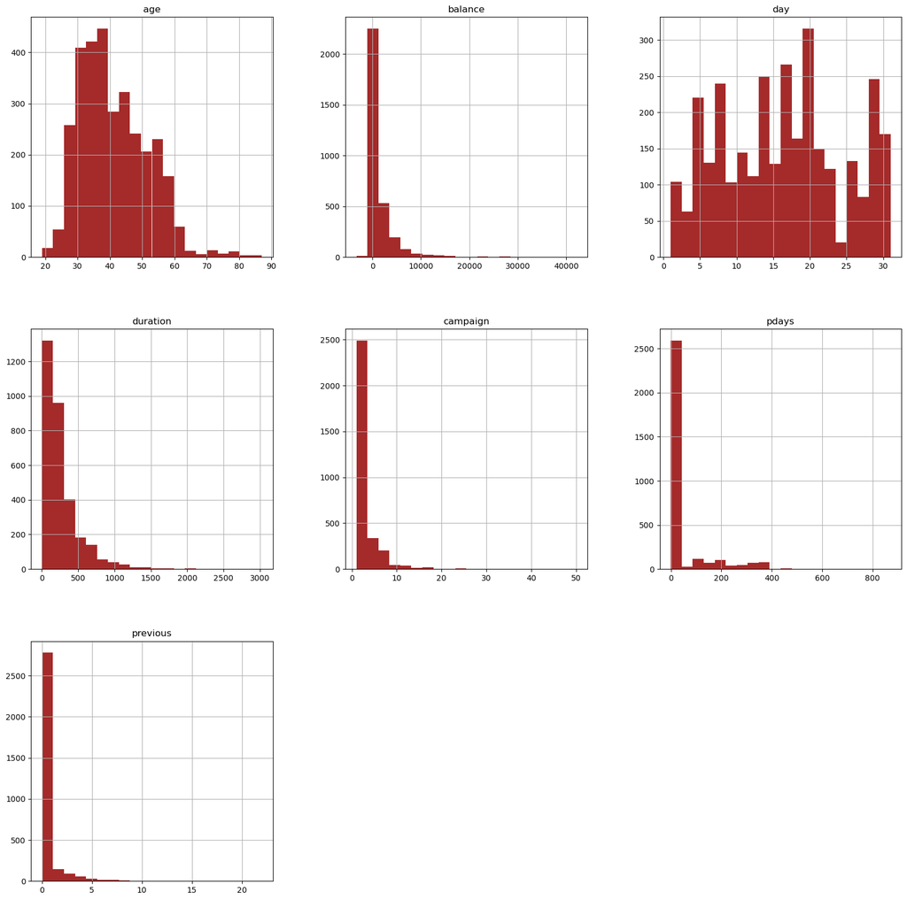

```python
# Numeryczne
bank_data.hist(figsize = (20, 20), bins = 20, color = "brown")
```

- Ludzie w wieku średnim głównie
- Większość ludzi jest na niewielkim plusie r/r (balance) - jeżeli na minusie to niewielkim
- Rozmowy trwają zwykle krótko (duration), wygląda na rozklad wykladniczy
- Większość ludzi ma pojedynczą styczność z kampanią (previous/pdays)

```python
# Funkcja pomocnicza do pokazywania procentów
def without_hue(ax, feature):
    total = len(feature)
    for p in ax.patches:
        percentage = '{:.1f}%'.format(100 * p.get_height()/total)
        x = p.get_x() + p.get_width() / 2 - 0.2
        y = p.get_y() + p.get_height()
        ax.annotate(percentage, (x, y), size = 12)
```

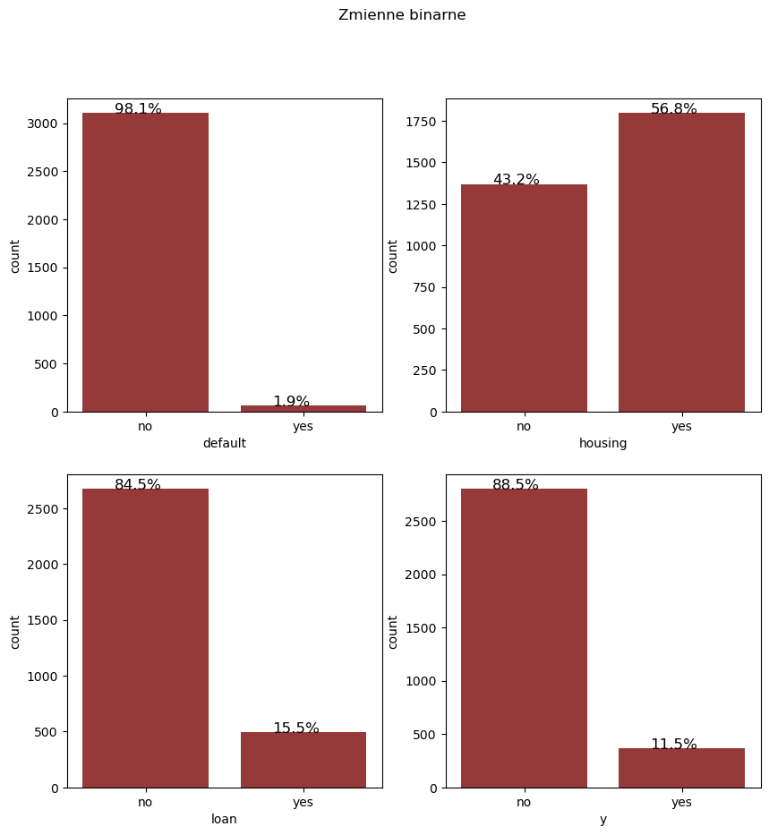

```python
# Binarne
fig, axs = plt.subplots(2, 2, figsize = (10, 10))
axs = axs.flatten()
fig.suptitle("Zmienne binarne")

for i, col in enumerate(binary):
    sns.countplot(data = bank_data, x = col, ax=axs[i], color = "brown", order=["no", "yes"])
    without_hue(axs[i], bank_data[col])
```

- Prawie nikt nie ma zaległych płatności kredytowych (credit)
- Mniej więcej tyle samo ma i nie ma kredytu mieszkaniowego (housing)
- Większość nie ma pożyczek indywidualnych (loan)
- Jedna na dziewięć z osób zgadza się na złożenie depozytu (y)

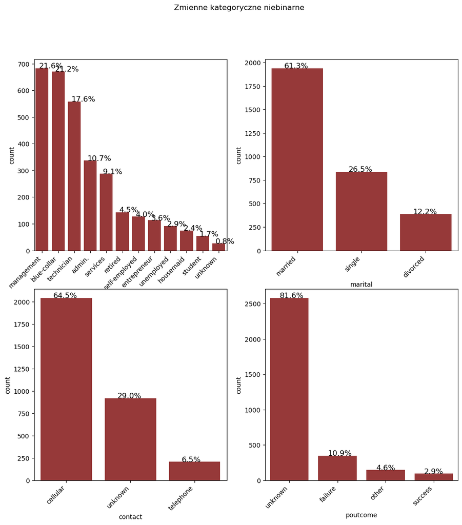

```python
# Kategoryczne
fig, axs = plt.subplots(2, 2, figsize = (12, 12))
axs = axs.flatten()
fig.suptitle("Zmienne kategoryczne niebinarne")

for i, col in enumerate(categorical):
    fig = sns.countplot(data = bank_data, x = col, ax=axs[i], color = "brown", order=bank_data[col].value_counts().index)
    fig.set_xticklabels(fig.get_xticklabels(), rotation=45, horizontalalignment='right')
    without_hue(axs[i], bank_data[col])
```

```python
# Czyli unknown w poutcome znaczy, że jest to pierwsza kampania przeprowadzona dla tego klienta po prostu
bank_data.loc[(bank_data["pdays"] == -1) & (bank_data["poutcome"] != "unknown")].size
```

```
0
```

- typowe zawody klasy średniej
- większość zamężna
- przez rozmowy telefoniczne/zdalne
- dla większości osób jest to pierwsza kampania przeprowadzona przez ten bank

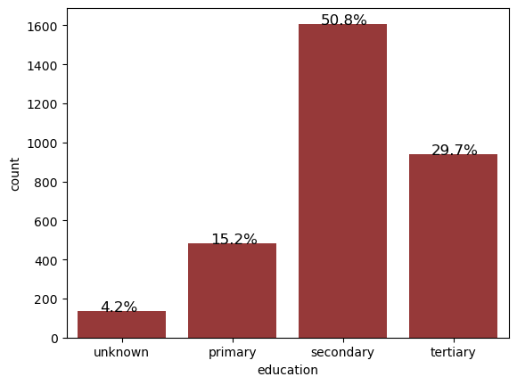

```python
# Oddzielnie bo jest uporządkowaną zmienną
fig = sns.countplot(data = bank_data, x = "education", color="brown", order=["unknown", "primary", "secondary", "tertiary"])
without_hue(fig, bank_data["education"])
```

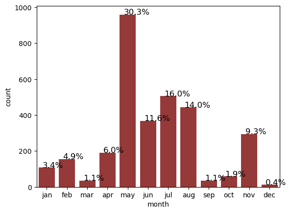

```python
# Widać, że więcej ludzi próbuje się namawiać w cieplejszych miesiącach
fig = sns.countplot(data = bank_data, x = "month", order=["jan", "feb", "mar", "apr", "may", "jun", "jul", "aug", "sep", "oct", "nov", "dec"], color = "brown")
without_hue(fig, bank_data["month"])
```

# Analiza ze względu na y

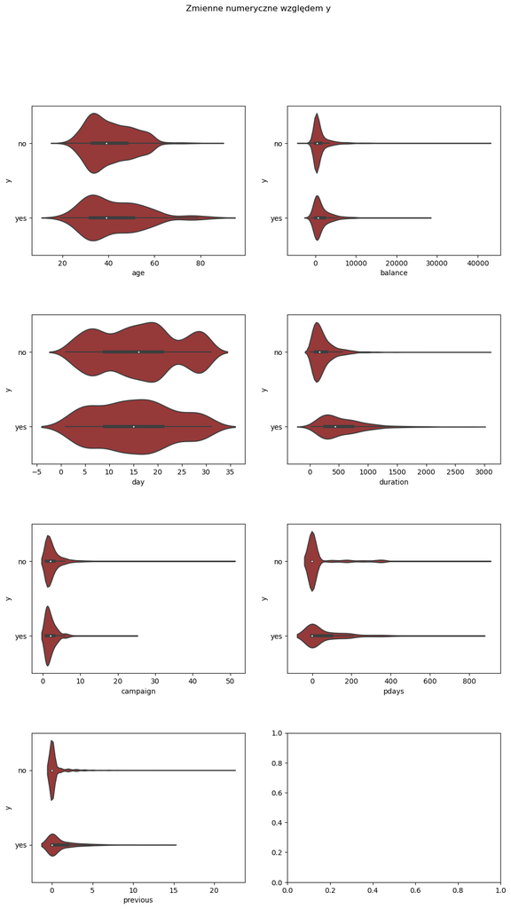

```python
fig, axs = plt.subplots(4, 2, figsize = (12, 20))
fig.subplots_adjust(hspace = 0.4)
fig.suptitle("Zmienne numeryczne względem y")

axs = axs.flatten()
for i, col in enumerate(["age", "balance", "day", "duration", "campaign", "pdays", "previous"]):
    sns.violinplot(data = bank_data, x = col, y ="y", color = "brown", ax = axs[i], orient="h")
```

Widać, że:

- ludzie starsi częściej (proporcjonalnie) mogą zostać namówieni
- długość trwania rozmowy ma ogromny wpływ na to czy dany człowiek zdecyduje się na założenie konta czy nie
- ludzie są chętniejsi do założenia konta, jeśli wcześniej mieli już styczność z jakąś kampanią prowadzoną przez ten bank(previous/pdays)

#### Kategoryczne

```python
# Do plotowania w określonej kolejności
bank_data["default"] = pd.Categorical(bank_data["default"], ["no", "yes"])
bank_data["housing"] = pd.Categorical(bank_data["housing"], ["no", "yes"])
bank_data["loan"] = pd.Categorical(bank_data["loan"], ["no", "yes"])
bank_data["education"] = pd.Categorical(bank_data["education"], ["unknown", "primary", "secondary", "tertiary"])
bank_data["poutcome"] = pd.Categorical(bank_data["poutcome"], ["unknown", "failure", "other", "success"])
bank_data["month"] = pd.Categorical(bank_data["month"], ["jan", "feb", "mar", "apr", "may", "jun", "jul", "aug", "sep", "oct", "nov", "dec"])
```

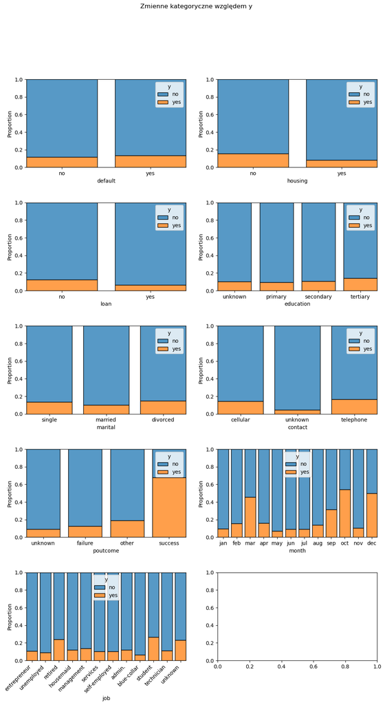

```python
cols = ["default", "housing", "loan", "education", "marital", "contact", "poutcome", "month", "job"]
fig, axs = plt.subplots(5, 2, figsize = (12, 20))
fig.subplots_adjust(hspace = 0.4)
fig.suptitle("Zmienne kategoryczne względem y")

axs = axs.flatten()
for i, col in enumerate(cols):
    fig = sns.histplot(data = bank_data, x = col, hue = "y", stat = "proportion", multiple = "fill", shrink=0.8, ax = axs[i])
    if col == "job":
        fig.set_xticklabels(fig.get_xticklabels(), rotation=45, horizontalalignment='right')
```

Wydaje się, że:

- Jeśli jesteśmy bez kredytu tojesteśmy chętniejsi powierzyć bankowi pieniądze
- Wydaje się, że im mamy wyższe wykształcenie tym chętniej założymy konto
- Rozmowy telefoniczne lepiej działają na klientów
- Ewidentnie jeśli w poprzedniej kampanii się udało klienta namówić to tym razem dużo łatwiej nam zaufa (ale jest to 3% obserwacji jedynie)
- Wydaje się cześciej udawać namówić klienta w marcu, wrześniu, październiku i grudniu, jednak obserwacje pochodzące z tych miesięcy stanowią ledwie 4.5% wszystkich obserwacji, tak naprawdę im częściej w danym miesiącu bombarduje się klientów kampanią tym rzadziej się udaje

```python
binary = ["default", "housing", "loan", "y"]
for i, col in enumerate(binary):
    bank_data[col] = bank_data[col].map({"no": 0, "yes": 1})
bank_data
```

|  | age | job | marital | education | default | balance | housing | loan | contact | day | month | duration | campaign | pdays | previous | poutcome | y |
| --- | --- | --- | --- | --- | --- | --- | --- | --- | --- | --- | --- | --- | --- | --- | --- | --- | --- |
| 0 | 37 | entrepreneur | single | tertiary | 0 | 1467 | 1 | 1 | cellular | 17 | nov | 349 | 1 | -1 | 0 | unknown | 0 |
| 1 | 25 | unemployed | single | secondary | 0 | 34 | 0 | 1 | unknown | 4 | jul | 316 | 1 | -1 | 0 | unknown | 0 |
| 2 | 53 | retired | married | secondary | 0 | 1278 | 1 | 0 | telephone | 15 | jul | 174 | 3 | -1 | 0 | unknown | 0 |
| 3 | 31 | housemaid | married | unknown | 1 | -6 | 0 | 1 | telephone | 7 | jul | 94 | 2 | -1 | 0 | unknown | 0 |
| 4 | 43 | unemployed | married | secondary | 0 | 3529 | 0 | 0 | cellular | 5 | feb | 169 | 2 | -1 | 0 | unknown | 0 |
| ... | ... | ... | ... | ... | ... | ... | ... | ... | ... | ... | ... | ... | ... | ... | ... | ... | ... |
| 3159 | 55 | services | divorced | primary | 0 | 653 | 0 | 0 | unknown | 6 | jun | 800 | 1 | -1 | 0 | unknown | 0 |
| 3160 | 39 | blue-collar | married | unknown | 0 | 0 | 0 | 0 | cellular | 2 | feb | 731 | 1 | 193 | 3 | failure | 0 |
| 3161 | 35 | technician | married | secondary | 0 | 0 | 0 | 0 | cellular | 14 | jul | 125 | 2 | -1 | 0 | unknown | 0 |
| 3162 | 37 | services | single | secondary | 0 | 105 | 0 | 1 | unknown | 17 | jun | 260 | 4 | -1 | 0 | unknown | 0 |
| 3163 | 63 | retired | married | secondary | 0 | 474 | 0 | 0 | cellular | 25 | jan | 423 | 1 | -1 | 0 | unknown | 1 |

3164 rows × 17 columns

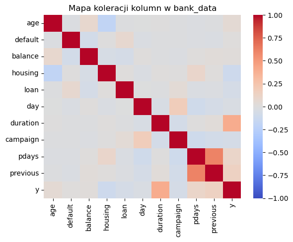

```python
df = bank_data.drop(["job", "marital", "education", "contact", "month", "poutcome"], axis=1)
fig = sns.heatmap(df.corr(), cmap = 'coolwarm', center = 0, vmax = 1, vmin = -1)
fig.set_title("Mapa koleracji kolumn w bank_data")
```

```python
bank_data.drop(["job", "marital", "education", "contact", "month", "poutcome"], axis=1).corr()
```

|  | age | default | balance | housing | loan | day | duration | campaign | pdays | previous | y |
| --- | --- | --- | --- | --- | --- | --- | --- | --- | --- | --- | --- |
| age | 1.000000 | -0.018724 | 0.078922 | -0.189160 | -0.010741 | -0.004456 | 0.003448 | -0.012465 | -0.016351 | -0.011463 | 0.054115 |
| default | -0.018724 | 1.000000 | -0.080135 | 0.007119 | 0.076243 | -0.026146 | -0.011460 | -0.013522 | -0.019795 | -0.024199 | 0.008731 |
| balance | 0.078922 | -0.080135 | 1.000000 | -0.048097 | -0.067202 | 0.015617 | -0.015518 | -0.022002 | 0.011831 | 0.030580 | 0.020315 |
| housing | -0.189160 | 0.007119 | -0.048097 | 1.000000 | 0.015357 | -0.024319 | 0.010051 | 0.006762 | 0.100293 | 0.013538 | -0.112209 |
| loan | -0.010741 | 0.076243 | -0.067202 | 0.015357 | 1.000000 | -0.004141 | -0.009676 | 0.039652 | -0.025904 | -0.017429 | -0.067591 |
| day | -0.004456 | -0.026146 | 0.015617 | -0.024319 | -0.004141 | 1.000000 | -0.039881 | 0.174478 | -0.098751 | -0.066724 | -0.036412 |
| duration | 0.003448 | -0.011460 | -0.015518 | 0.010051 | -0.009676 | -0.039881 | 1.000000 | -0.076595 | 0.004572 | 0.024641 | 0.399869 |
| campaign | -0.012465 | -0.013522 | -0.022002 | 0.006762 | 0.039652 | 0.174478 | -0.076595 | 1.000000 | -0.104030 | -0.085033 | -0.064334 |
| pdays | -0.016351 | -0.019795 | 0.011831 | 0.100293 | -0.025904 | -0.098751 | 0.004572 | -0.104030 | 1.000000 | 0.605961 | 0.108315 |
| previous | -0.011463 | -0.024199 | 0.030580 | 0.013538 | -0.017429 | -0.066724 | 0.024641 | -0.085033 | 0.605961 | 1.000000 | 0.147231 |
| y | 0.054115 | 0.008731 | 0.020315 | -0.112209 | -0.067591 | -0.036412 | 0.399869 | -0.064334 | 0.108315 | 0.147231 | 1.000000 |

- oczywista koleracja między previous, a pdays (jeśli kontaktowaliśmy się z klientem w poprzedniej kampanii - previous dodatnie, to mamy spore pdays, a w większości nie kontaktowaliśmy się wcześniej z danym klientem, czyli pdays = -1)

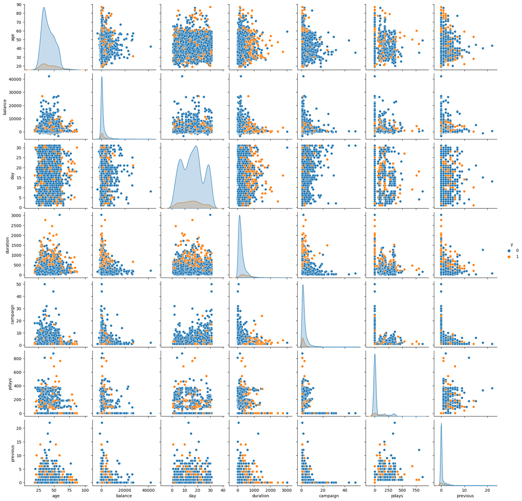

```python
fig = sns.pairplot(bank_data, hue = "y")
```

- Możliwe, że połączenie zmiennych duration z campaign spowoduje łatwiejsze rozdzielenie ludzi na grupy
- Tak samo możliwe z age
- Jednak tego typu ploty mają problem z tym, że najważniejsze okazują się dane na końcu "wyplotowane", czyli zobaczymy głównie obserwacje z końca naszej ramki danych(gdyż program robiący wykres nakłada na siebie punkty). Żeby mieć pewność co do oceny, czy można rozdzielać wg danej grupy przydałoby się zliczać zatem jakąś proporcję w danych obszarach. Stąd pomysł na kolejne heatmapy

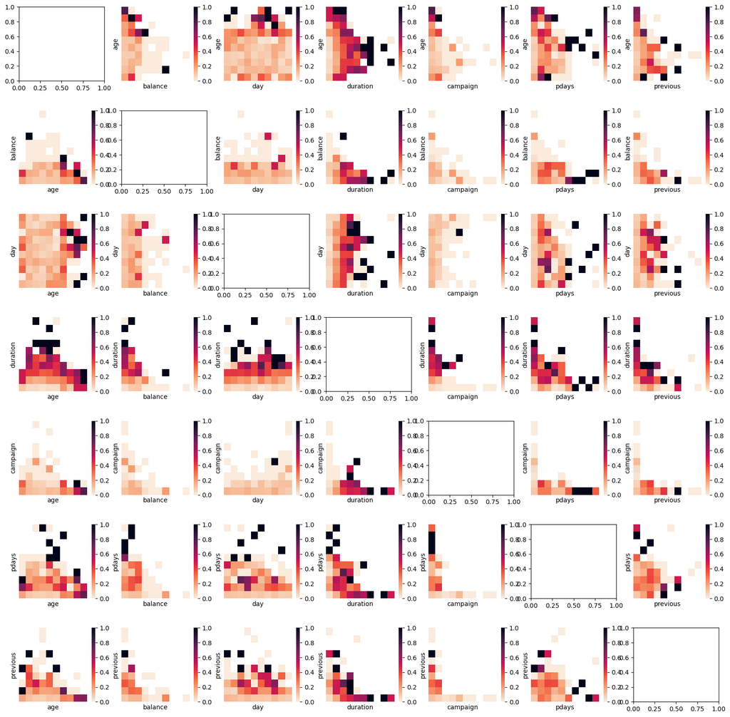

```python
bins = 10
fig, axs = plt.subplots(7, 7, figsize = (20, 20))
fig.subplots_adjust(hspace = 0.4)

for i, col1 in enumerate(["age", "balance", "day", "duration", "campaign", "pdays", "previous"]):
    for j, col2 in enumerate(["age", "balance", "day", "duration", "campaign", "pdays", "previous"]):
        if i != j:
            df = pd.DataFrame({col1: pd.cut(bank_data[col1], bins = bins),\
                  col2: pd.cut(bank_data[col2], bins = bins),\
                  "y": bank_data["y"].copy()})
            df = df.groupby([col1, col2]).mean().reset_index().pivot(index=col1, columns=col2, values="y").sort_index(ascending = False)
            fig = sns.heatmap(df, cmap = sns.cm.rocket_r, ax = axs[i][j], vmin=0, vmax=1)
            fig.tick_params(labelleft=False, left=False, labelbottom=False, bottom=False)
```

- Tutaj zastosowane były równy przedział kubełków co spowodowało nadmiernie skupienie się nasycenia kolorów (a zatem też naszych oczu) na outlierach, co nie powinno być celem tego wykresu. Stąd zrobimy równe kubełki i zobaczymy co się stanie

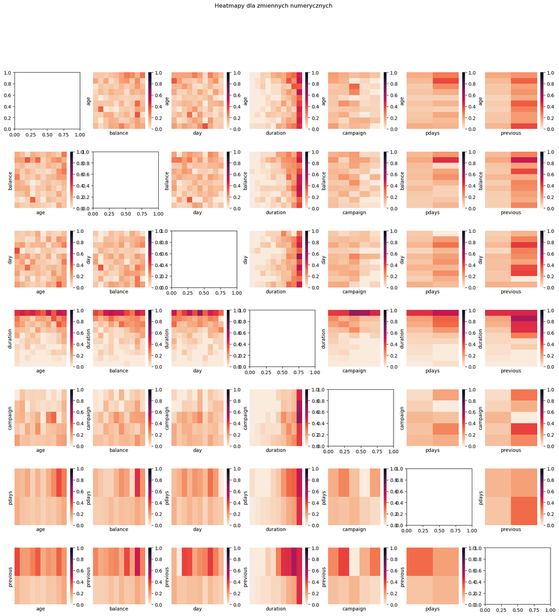

```python
#Tutaj dla równych binów (wg ilosci wpadajacych do binow)
bins = 10
fig, axs = plt.subplots(7, 7, figsize = (20, 20))
fig.subplots_adjust(hspace = 0.4)
fig.suptitle("Heatmapy dla zmiennych numerycznych")

for i, col1 in enumerate(["age", "balance", "day", "duration", "campaign", "pdays", "previous"]):
    for j, col2 in enumerate(["age", "balance", "day", "duration", "campaign", "pdays", "previous"]):
        if i != j:
            df = pd.DataFrame({col1: pd.qcut(bank_data[col1], q = bins, duplicates = "drop"),\
                  col2: pd.qcut(bank_data[col2], q = bins, duplicates = "drop"),\
                  "y": bank_data["y"].copy()})
            df = df.groupby([col1, col2]).mean().reset_index().pivot(index=col1, columns=col2, values="y").sort_index(ascending = False)
            fig = sns.heatmap(df, cmap = sns.cm.rocket_r, ax = axs[i][j], vmin=0, vmax=1)
            fig.tick_params(labelleft=False, left=False, labelbottom=False, bottom=False)
```

- Po wrzuceniu outlierów do skrajnych kubełków obraz wydaje się być bardziej rzeczywisty.
- Widać ewidentną zależność dla cechy duration, że ma ona wysoki wpływ prawdopodobieństwo założenia depozytu nie zależnie od drugiej cechy
- W niektórych subplotach "zmniejszyła się" liczba kubełków na niektórych osiach. Ma to związek z tym, że funkcja qcut stara się podzielić kubełki na równe. Jednak na początku zauważyliśmy, że wiele z naszych cech ma mocno skośny rozkład (w dodatku są to inty) stąd nie mógł równo podzielić na wcześniej zaznaczoną ilość unikalnych kubełków. Stąd dałem możliwość zredukowania ilości kubełków w takim przypadku (duplicates="drop"), aby obsłużyć taki przypadek
- W takiej reprezentacji można zauważyć też, że previous mocno wpływa na prawdopodobieństwo przy uwzględnieniu duration. Oczywiście można to wytłumaczyć tym, że człowiek, który miał już styczność poprzednio z tym bankiem chętniej dowie się więcej o ofercie i końcowo zdecyduje się na proponowany produkt/założenie depozytu.
- Oprócz tego okazuje się, że zmienna balance ma wpływ tzn, że ludzie, którzy wychodzą na dużym plusie r/r chętniej założą konto jeśli wcześniej mieli kontakt z danym bankiem (plot previous/balance)

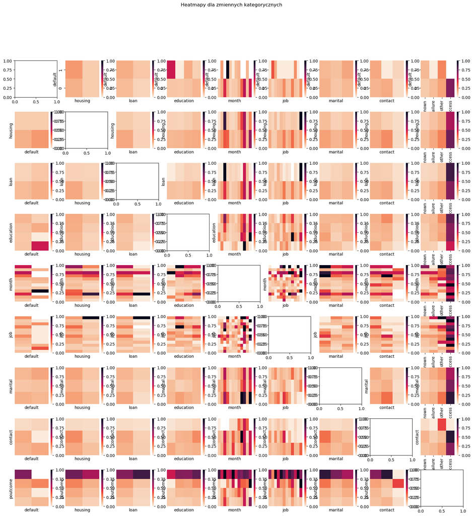

```python
fig, axs = plt.subplots(9, 9, figsize = (20, 20))
fig.subplots_adjust(hspace = 0.4)
fig.suptitle("Heatmapy dla zmiennych kategorycznych")

for i, col1 in enumerate(["default", "housing", "loan", "education", "month", "job", "marital", "contact", "poutcome"]):
    for j, col2 in enumerate(["default", "housing", "loan", "education", "month", "job", "marital", "contact", "poutcome"]):
        if i != j:
            df = bank_data[[col1, col2, "y"]].groupby([col1, col2]).mean().unstack(fill_value=0).stack().reset_index().pivot(index=col1, columns=col2, values="y").sort_index(ascending = False)
            if i == 0 and j == 8:
                fig = sns.heatmap(df, cmap = sns.cm.rocket_r, ax = axs[i][j], vmin=0, vmax=1)
            elif i == 0 and j != 8:
                fig = sns.heatmap(df, cmap = sns.cm.rocket_r, ax = axs[i][j], vmin=0, vmax=1, xticklabels=False)
            elif j == 8 and i != 0:
                fig = sns.heatmap(df, cmap = sns.cm.rocket_r, ax = axs[i][j], vmin=0, vmax=1, yticklabels=False)
            else:
                fig = sns.heatmap(df, cmap = sns.cm.rocket_r, ax = axs[i][j], vmin=0, vmax=1, xticklabels=False, yticklabels = False)
```

- te ploty są dla zmiennych kategorycznych, czyli kubełki nie są podzielone równo, stąd nasycenie kolorów jest wysokie
- widać zależności ewidentne od poutcome w każdym przypadku w przypadku sukcesu
- ploty te zostały zrobione, żeby ewentualnie zajrzeć do środka do poszczególnych plotów pojedynczo

```python
# Tą funkcją możemy wchodzić do poszególnych plotów tak, żeby zobaczyć dla jakich kategorii co jest
def make_categorical_heatmap(col1, col2):
    df = bank_data[[col1, col2, "y"]].groupby([col1, col2]).mean().unstack(fill_value=0).stack().reset_index().pivot(index=col1, columns=col2, values="y").sort_index(ascending = False)
    annot = bank_data[[col1, col2, "y"]].groupby([col1, col2]).count().unstack(fill_value=0).stack().reset_index().pivot(index=col1, columns=col2, values="y").sort_index(ascending = False)
    fig = sns.heatmap(df, cmap = sns.cm.rocket_r, vmin=0, vmax=1, annot = annot, fmt='g')
    fig.set_xticklabels(fig.get_xticklabels(), rotation=45, horizontalalignment='right')
    plt.show()
```

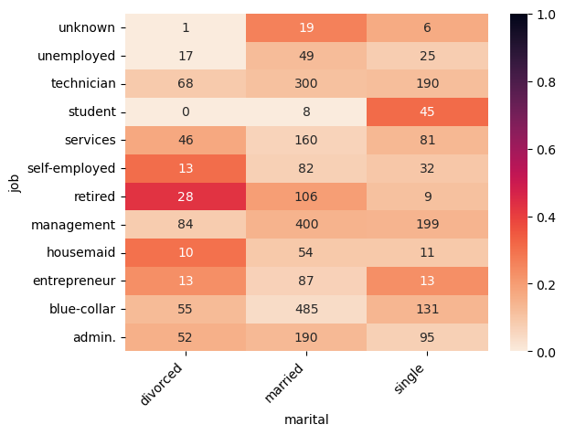

```python
# Liczba w środku informuje nas ile w tym kubełku razem było obserwacji (bo wiemy, że kategorie nie są równo podzielone)
# W ten sposób kolory nas nie zmylą, jeśli będą to outliery (rzadkie kombinacje)
make_categorical_heatmap("job", "marital")
```

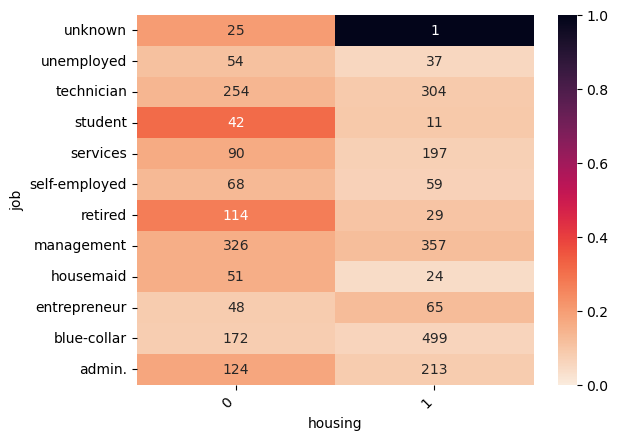

```python
# Widać, że ludzie niepracujący (retired i student) nie mający kredytu hipotecznego mają sporą szanse na założenie konta
make_categorical_heatmap("job", "housing")
```

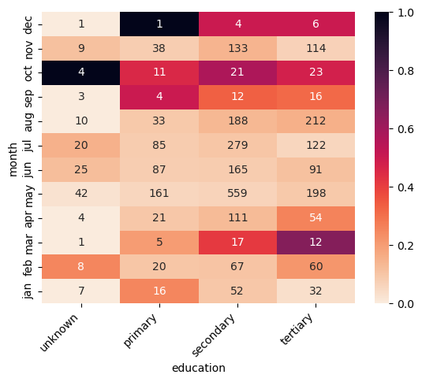

```python
make_categorical_heatmap("month", "education")
```

- Postanowiliśmy nie zajmować się (przynajmniej na razie) analizą pojedynczych kombinacji zmiennych kategorycznych. Możliwe, że jeszcze do tego wrócimy, jeśli będziemy potrzebować takich kombinacji podczas trenowania modeli, jednak w tym momencie nie wydaje się, by to było jakoś bardzo istotne w kierunku szukania trendów dla danych